# Exercise 6.6.3 - Testing OLS Assumptions

W. Mangrobang

September 07, 2018

### Problem Statement

Build a regression model using at least three predictor variables. Consider using the AutoClaim or diamonds datasets, but any data you have will do. The purpose of this exercise is to perform various tests of the assumptions for ordinary least squares regression. When finished, report on the forum your dataset choice, your target and predictor variables, and which of the assumptions appear to have been met. CHUNK 12 has some code snippets that may help.

**+ The mean of the residuals is zero (note that in most cases this is an assured outcome of the parameter estimation process).**

**+ The variance is constant (homoscedasticity). Residual plots are commonly used. R makes four useful plots.**

- The residuals have no autocorrelation. We have not had a time series component to our data. With no preset order to the observations, it makes no sense to check this assumption.

**+ The residuals and the predictor variables are uncorrelated. A hypothesis test that the correlation is zero can be done.**

**+ The residuals have a normal distribution. This can be checked via a q- q plot or a histogram.**

- I selected the `diamonds` dataset.
- Target variable: `price`
- Predictor variables: `depth`, `table`, `caret`

```r
# CHUNK 12
library(ggplot2)
# load your dataset, if not already loaded
data("diamonds")
dim(diamonds)
```

```
## [1] 53940    10
```

```r
head(diamonds)
```

```
## # A tibble: 6 x 10
##   carat cut       color clarity depth table price     x     y     z
##   <dbl> <ord>     <ord> <ord>   <dbl> <dbl> <int> <dbl> <dbl> <dbl>
## 1 0.23  Ideal     E     SI2      61.5    55   326  3.95  3.98  2.43
## 2 0.21  Premium   E     SI1      59.8    61   326  3.89  3.84  2.31
## 3 0.23  Good      E     VS1      56.9    65   327  4.05  4.07  2.31
## 4 0.290 Premium   I     VS2      62.4    58   334  4.2   4.23  2.63
## 5 0.31  Good      J     SI2      63.3    58   335  4.34  4.35  2.75
## 6 0.24  Very Good J     VVS2     62.8    57   336  3.94  3.96  2.48
```

```r
head(diamonds)
```

```
## # A tibble: 6 x 10
##   carat cut       color clarity depth table price     x     y     z
##   <dbl> <ord>     <ord> <ord>   <dbl> <dbl> <int> <dbl> <dbl> <dbl>
## 1 0.23  Ideal     E     SI2      61.5    55   326  3.95  3.98  2.43
## 2 0.21  Premium   E     SI1      59.8    61   326  3.89  3.84  2.31
## 3 0.23  Good      E     VS1      56.9    65   327  4.05  4.07  2.31
## 4 0.290 Premium   I     VS2      62.4    58   334  4.2   4.23  2.63
## 5 0.31  Good      J     SI2      63.3    58   335  4.34  4.35  2.75
## 6 0.24  Very Good J     VVS2     62.8    57   336  3.94  3.96  2.48
```

```r
summary(diamonds)
```

```
##      carat               cut        color        clarity
##  Min.   :0.2000   Fair     : 1610   D: 6775   SI1    :13065
##  1st Qu.:0.4000   Good     : 4906   E: 9797   VS2    :12258
##  Median :0.7000   Very Good:12082   F: 9542   SI2    : 9194
##  Mean   :0.7979   Premium  :13791   G:11292   VS1    : 8171
##  3rd Qu.:1.0400   Ideal    :21551   H: 8304   VVS2   : 5066
##  Max.   :5.0100                     I: 5422   VVS1   : 3655
##                                     J: 2808   (Other): 2531
##      depth           table           price             x
##  Min.   :43.00   Min.   :43.00   Min.   :  326   Min.   : 0.000
##  1st Qu.:61.00   1st Qu.:56.00   1st Qu.:  950   1st Qu.: 4.710
##  Median :61.80   Median :57.00   Median : 2401   Median : 5.700
##  Mean   :61.75   Mean   :57.46   Mean   : 3933   Mean   : 5.731
##  3rd Qu.:62.50   3rd Qu.:59.00   3rd Qu.: 5324   3rd Qu.: 6.540
##  Max.   :79.00   Max.   :95.00   Max.   :18823   Max.   :10.740
##
##        y                z
##  Min.   : 0.000   Min.   : 0.000
##  1st Qu.: 4.720   1st Qu.: 2.910
##  Median : 5.710   Median : 3.530
##  Mean   : 5.735   Mean   : 3.539
##  3rd Qu.: 6.540   3rd Qu.: 4.040
##  Max.   :58.900   Max.   :31.800
##
```

```r
str(diamonds)
```

```
## Classes 'tbl_df', 'tbl' and 'data.frame':    53940 obs. of  10 variables:
##  $ carat  : num  0.23 0.21 0.23 0.29 0.31 0.24 0.24 0.26 0.22 0.23 ...
##  $ cut    : Ord.factor w/ 5 levels "Fair"<"Good"<..: 5 4 2 4 2 3 3 3 1 3 ...
##  $ color  : Ord.factor w/ 7 levels "D"<"E"<"F"<"G"<..: 2 2 2 6 7 7 6 5 2 5 ...
##  $ clarity: Ord.factor w/ 8 levels "I1"<"SI2"<"SI1"<..: 2 3 5 4 2 6 7 3 4 5 ...
##  $ depth  : num  61.5 59.8 56.9 62.4 63.3 62.8 62.3 61.9 65.1 59.4 ...
##  $ table  : num  55 61 65 58 58 57 57 55 61 61 ...
##  $ price  : int  326 326 327 334 335 336 336 337 337 338 ...
##  $ x      : num  3.95 3.89 4.05 4.2 4.34 3.94 3.95 4.07 3.87 4 ...
##  $ y      : num  3.98 3.84 4.07 4.23 4.35 3.96 3.98 4.11 3.78 4.05 ...
##  $ z      : num  2.43 2.31 2.31 2.63 2.75 2.48 2.47 2.53 2.49 2.39 ...
```

```r
# run the regression
model <- lm(price ~ depth + table + carat, data = diamonds)
```

*+ The mean of the residuals is zero (note that in most cases this is an assured outcome of the parameter estimation process).*

```r
# Check the mean of the residuals
mean(model$residuals)
```

```
## [1] -1.938156e-12
```

Basically zero.

*+ The variance is constant (homoscedasticity). Residual plots are commonly used. R makes four useful plots.*

*+ Check that the residuals have a normal distribution*

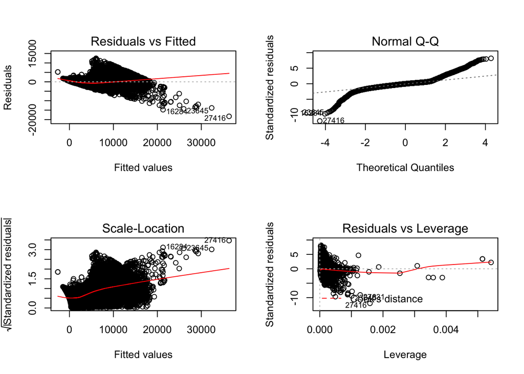

```r
# Check the residuals for constant variance. Not all four plots relate to
# this assumption.
par(mfrow = c(2, 2))
plot(model)
```

Homoscedasticity - Fails. Note the Scale-Location plot and how there appears to be a distintive shape/pattern to the scatter. With constant variance we expect to see an even, shapeless distribution across the plot.

Normality - Fails. For the QQ-Plot, we expect to see points to align along the 45 degree line across all quantiles. This is the case in the middle quantiles, but the ends diverge significantly.

*…Another option is to make a histogram of the residuals.*

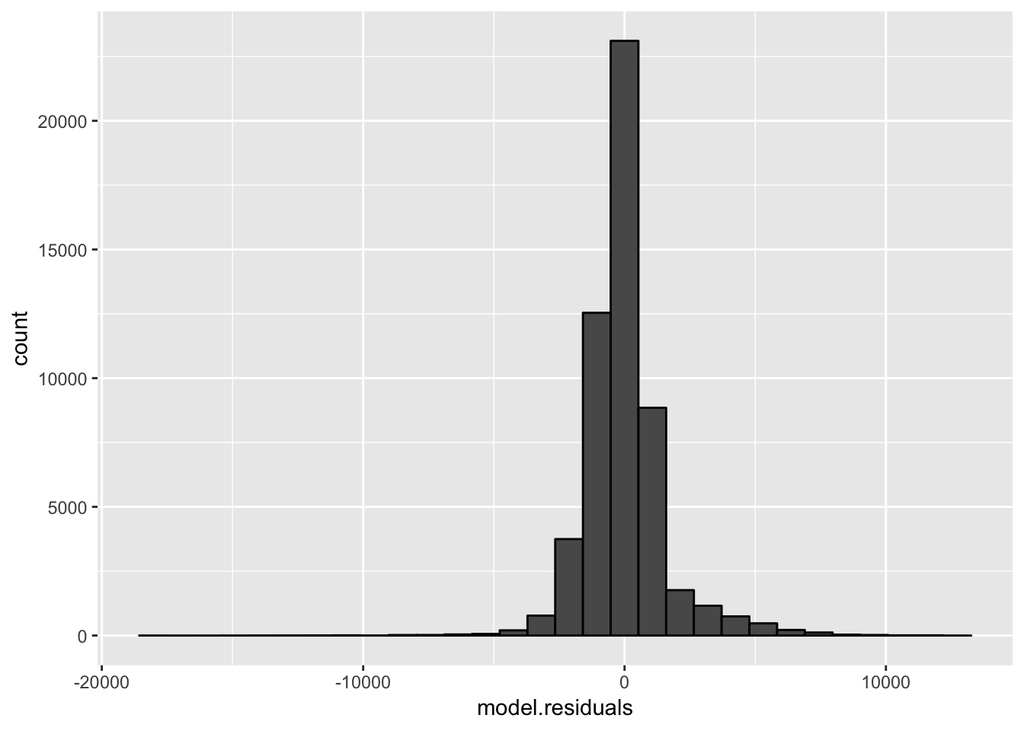

```r
resid <- data.frame(model$residuals)
ggplot(resid, aes(x = model.residuals)) + geom_histogram(position = "identity",
    col = "black")
```

It seems roughly ‘bell-shaped’ but qq-plot tells a clearer story of normality failure at the tails.

*Check that the residuals and the predictor variables are uncorrelated*

```r
cor.test(diamonds$depth, model$residuals, method = "pearson")
```

```
##
##  Pearson's product-moment correlation
##
## data:  diamonds$depth and model$residuals
## t = 1.6268e-13, df = 53938, p-value = 1
## alternative hypothesis: true correlation is not equal to 0
## 95 percent confidence interval:
##  -0.008439066  0.008439066
## sample estimates:
##          cor
## 7.004606e-16
```

```r
cor.test(diamonds$table, model$residuals, method = "pearson")
```

```
##
##  Pearson's product-moment correlation
##
## data:  diamonds$table and model$residuals
## t = 7.8554e-13, df = 53938, p-value = 1
## alternative hypothesis: true correlation is not equal to 0
## 95 percent confidence interval:
##  -0.008439066  0.008439066
## sample estimates:
##          cor
## 3.382372e-15
```

```r
cor.test(diamonds$carat, model$residuals, method = "pearson")
```

```
##
##  Pearson's product-moment correlation
##
## data:  diamonds$carat and model$residuals
## t = -3.632e-13, df = 53938, p-value = 1
## alternative hypothesis: true correlation is not equal to 0
## 95 percent confidence interval:
##  -0.008439066  0.008439066
## sample estimates:
##           cor
## -1.563883e-15
```

Appears that residuals are uncorrelated with all three target variables.  
+ High p-values suggest not rejecting the null hypothesis that the correlation is 0.  
+ The 95% confidence intervals are centered around 0.